# OSM Extracting Amenities

Antonio Paez

2024-10-17

**NOTE:** Notebook takes minutes to run.

In this document I collect and preprocess the OSM data with amenities.

# Preliminaries

Load packages:

```r
library(dplyr) # A Grammar of Data Manipulation
library(forcats) # Tools for Working with Categorical Variables (Factors)
library(ggplot2) # Create Elegant Data Visualisations Using the Grammar of Graphics
library(glue) # Interpreted String Literals
library(h3) # R Bindings for H3
library(here) # A Simpler Way to Find Your Files
library(osmdata) # Import 'OpenStreetMap' Data as Simple Features or Spatial Objects
library(purrr) # Functional Programming Tools
library(sf) # Simple Features for R
library(tidyr) # Tidy Messy Data
library(units) # Measurement Units for R Vectors
library(vaccHamilton) # A Data Package to Estimate Accessibility of Vaccination Sites in Hamilton, ON
```

Load data objects from package {vaccHamilton}. Urban types is the way the City of Hamilton classifies different parts of the city as “Urban”, “Suburban”, and “Rural”:

```r
data("urban_types")
#data("data_da_2016")
```

Use only urban and suburban Hamilton:

```r
urban_hammer <- urban_types |>
  filter(Type != "Rural")
```

# Obtain amenities

Set the bounding box to the extent of urban/suburban Hamilton:

```r
b <- st_bbox(urban_hammer |>
               st_transform(crs = 4326))
```

Initialize the query:

```r
amenities <- opq(bbox = b) |>
  add_osm_feature(key = "amenity") |>
  osmdata_sf()
```

The number of amenities retrieved is:

```r
nrow(amenities$osm_points)
```

```
[1] 59497
```

See OSM documentation for relevant amenities: https://wiki.openstreetmap.org/wiki/Key:amenity

```r
summary(factor(amenities$osm_points$amenity))
```

```
            art_school            arts_centre                    atm                   bank           banquet_hall                    bar
                     1                      3                     20                     81                      3                     22
                   bbq                  bench        bicycle_parking         bicycle_rental bicycle_repair_station            boat_rental
                     9                    583                    201                    115                      8                      1
      bureau_de_change            bus_station                   cafe             car_rental            car_sharing               car_wash
                     4                     10                    169                      5                      8                     13
                casino       charging_station              childcare  childrens_aid_society           chiropractor                 cinema
                     1                      9                      5                      1                      1                      4
                clinic                  clock      clothing_donation                college       community_centre             courthouse
                    33                      5                      3                      3                     11                      1
       coworking_space                dentist                doctors                   dojo          dressing_room         drinking_water
                     1                     94                     33                      1                      3                     23
        driving_school           events_venue              fast_food         ferry_terminal           fire_station             food_court
                     5                      3                    420                      2                      8                      7
              fountain                   fuel             grave_yard               grit_bin               hospital              ice_cream
                     6                     93                      1                      2                      1                     24
          kindergarten             letter_box                library           loading_dock            marketplace           music_school
                     9                      3                     16                     37                      5                      2
             nightclub          parcel_locker                parking       parking_entrance          parking_space           pest_control
                     1                      1                     67                     77                      5                      1
              pharmacy       place_of_worship                 police               post_box            post_office            prep_school
                    98                     58                      5                    419                     23                      8
                presto                    pub            public_bath        public_bookcase              recycling              relay_box
                     1                     48                      3                     14                     28                      8
            restaurant                 school                shelter          social_centre        social_facility                 studio
                   391                      2                     43                      1                      5                      4
                  taxi              telephone                theatre                toilets                 towing            trolley_bay
                     2                     42                      5                     44                      1                      7
              tutoring                 vacant        vending_machine             veterinary           waste_basket waste_basket;recycling
                     1                      6                     14                     19                    159                      8
        waste_disposal            water_point            weighbridge                   NA's
                     3                      1                      1                  55741
```

Notice the large number of NAs.

Refine search by segmenting the categories of amenities.

Sustenance:

```r
sustenance <- opq(bbox = b) |>
  add_osm_features(c("\"amenity\"=\"bar\"",
                     "\"amenity\"=\"biergarten\"",
                     "\"amenity\"=\"cafe\"",
                     "\"amenity\"=\"fast_food\"",
                     "\"amenity\"=\"food_court\"",
                     "\"amenity\"=\"ice_cream\"",
                     "\"amenity\"=\"pub\"",
                     "\"amenity\"=\"restaurant\"")) |>
  osmdata_sf()
```

Check the output:

```r
summary(factor(sustenance$osm_points$amenity))
```

```
       bar       cafe  fast_food food_court  ice_cream        pub restaurant       NA's
        22        169        420          7         24         48        391       1803
```

Extract the points and add a column with the category “Sustenance”:

```r
sustenance_points <- sustenance$osm_points |>
  mutate(Category = "Sustenance")
```

Education:

```r
education <- opq(bbox = b) |>
  add_osm_features(c("\"amenity\"=\"library\"",
                     "\"amenity\"=\"school\"")) |>
  osmdata_sf()
```

Check the output:

```r
summary(factor(education$osm_points$amenity))
```

```
library  school    NA's
     16       2    1969
```

Extract the points, remove the schools and NAs and add a column with the category “Library”:

```r
library_points <- education$osm_points |>
  filter(amenity == "library") |>
  mutate(Category = "Library")
```

Financial:

```r
financial <- opq(bbox = b) |>
  add_osm_features(c("\"amenity\"=\"atm\"",
                     "\"amenity\"=\"bank\"",
                     "\"amenity\"=\"bureau_de_change\"")) |>
  osmdata_sf()
```

Check the output:

```r
summary(factor(financial$osm_points$amenity))
```

```
             atm             bank bureau_de_change             NA's
              20               81                4              245
```

Possibly 200+ banks and atms not labeled?

```r
financial_points <- education$osm_points |>
  mutate(Category = "Financial")
```

Health services:

```r
healthcare <- opq(bbox = b) |>
  add_osm_features(c("\"amenity\"=\"clinic\"",
                     "\"amenity\"=\"dentist\"",
                     "\"amenity\"=\"doctors\"",
                     "\"amenity\"=\"pharmacy\"")) |>
  osmdata_sf()
```

Check the output:

```r
summary(factor(healthcare$osm_points$amenity))
```

```
  clinic  dentist  doctors pharmacy     NA's
      33       94       33       98      327
```

```r
healthcare_points <- healthcare$osm_points |>
  mutate(Category = "Healthcare")
```

Bind all amenity categories as points:

```r
amenities_points <- rbind(sustenance_points |>
                            select(osm_id, name, amenity, Category),
                          library_points |>
                            select(osm_id, name, amenity, Category),
                          financial_points |>
                            select(osm_id, name, amenity, Category),
                          healthcare_points |>
                            select(osm_id, name, amenity, Category))
```

Plot:

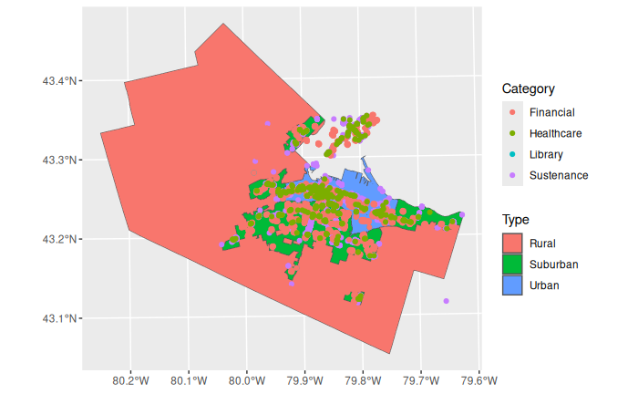

```r
ggplot() +
  geom_sf(data = urban_types,
          aes(fill = Type)) +
  geom_sf(data = amenities_points,
          aes(color = Category))
```

Obtain the h3 indices at level 13 from the simple features object:

```r
amenities_h3 <- geo_to_h3(amenities_points, res = 13)
```

Add h3 indices to amenities_points data object:

```r
amenities_points$h3_index <- amenities_h3
```

Save the data objects:

```r
save(sustenance,
     file = paste0(here::here(),
                   "/data/sustenance.rda"),
     compress = "xz")
save(education, file = paste0(here::here(),
                   "/data/education.rda"),
     compress = "xz")
save(financial, file = paste0(here::here(),
                   "/data/financial.rda"),
     compress = "xz")
save(healthcare, file = paste0(here::here(),
                   "/data/healthcare.rda"),
     compress = "xz")
save(amenities_points, file = paste0(here::here(),
                   "/data/amenities_points.rda"),
     compress = "xz")
```

Append type of urban fabric to amenities:

```r
amenities_by_type <- amenities_points |>
  select(Category) |>
  st_transform(crs = st_crs(urban_types)) |>
  st_intersection(urban_types)
```

Summarize number of amenities by category by urban type:

```r
amenities_by_type <- amenities_by_type |>
  st_drop_geometry() |>
  group_by(Type) |>
  group_map(~table(.x$Category))

amenities_by_type
```

```
[[1]]

 Financial    Library Sustenance
        60          1         16

[[2]]

 Financial Healthcare    Library Sustenance
      1044        302          7       1264

[[3]]

 Financial Healthcare    Library Sustenance
       612        206          7       1205
```

```r
area_by_type <- urban_hammer |>
  mutate(area = st_area(geometry) |>
           units::set_units(km2))

area_by_type
```

```
Simple feature collection with 2 features and 2 fields
Geometry type: GEOMETRY
Dimension:     XY
Bounding box:  xmin: 577850.9 ymin: 4774053 xmax: 611891.5 ymax: 4800615
Projected CRS: NAD83 / UTM zone 17N
```

|  | Type | geometry | area |
| --- | --- | --- | --- |
| 1 | Suburban |  | 163.88334 [km2] |
| 2 | Urban |  | 76.23458 [km2] |

What is the density of amenities in each of these two urban fabrics?

```r
suburban_density <- amenities_by_type[[2]]/drop_units(area_by_type$area[1])
urban_density <- amenities_by_type[[3]]/drop_units(area_by_type$area[2])

data.frame(suburban = suburban_density,
           urban = urban_density) |>
  mutate(ratio = urban.Freq/suburban.Freq) |>
  transmute(Category = suburban.Var1,
            suburban_density = set_units(suburban.Freq, 1/km2),
            urban_density = set_units(urban.Freq, 1/km2),
            ratio)
```

| Category | suburban_density | urban_density | ratio |
| --- | --- | --- | --- |
| Financial | 6.37038530 [1/km2] | 8.02785321 [1/km2] | 1.260183 |
| Healthcare | 1.84277429 [1/km2] | 2.70218589 [1/km2] | 1.466368 |
| Library | 0.04271331 [1/km2] | 0.09182185 [1/km2] | 2.149724 |
| Sustenance | 7.71280366 [1/km2] | 15.80647569 [1/km2] | 2.049381 |